# TFT Augments and Traits: Set 6.5 Patch 12.8

## Pickrate vs Average Placement of Augments

Next, we will look at the pickrate and average placement of different augments.

First, we create a default dictionary with an empty list as the default value to contain our data. Then, for each row in our dataframe, we scan through each augment in the "Augment_1", "Augment_2", and "Augment_3" and add the placement of the row to the corresponding list in the dictionary. By the end of this process, we have a dictionary with its keys as the augments, and the values as lists containing all the placements of different augments

```python
augments_winrate = defaultdict( lambda: [] )

for index, row in df.iterrows():
    for augment in ['Augment_1', 'Augment_2', 'Augment_3']:
        if type(row[augment]) != float:
            augments_winrate[row[augment]].append(row['Placement'])
```

Next, we create code to generate the data we will use to plot the graph based on this dictionary. First, we create three lists, x to keep track of the pickrate, y to keep track of the average placement, and keys to keep track of which augment corresponds to each pickrate and average placement. Then, we iterate through the dictionary, adding to these respective lists. Keys will simply add the key of the dictionary entry, x will receive the pickrate as a percentage by dividing the number of placements by the total number of boards observed, and y will append the average of the list within the value of the dictionary.

```python
x = []
y = []
keys = []
rows = []
for key, values in augments_winrate.items():
    keys.append(key)
    x.append(len(values) / len(df.index) * 100)
    y.append(sum(values) / len(values))

aug_pick_win = pd.DataFrame(data={'Augment': keys, 'Pickrate': x, 'Average Placement': y})
aug_pick_win
```

|  | Augment | Pickrate | Average Placement |
| --- | --- | --- | --- |
| 0 | TFT6_Augment_TreasureTrove1 | 4.057279 | 4.411765 |
| 1 | TFT6_Augment_FourScore | 2.595465 | 4.706897 |
| 2 | TFT6_Augment_SunfireBoard | 2.177804 | 4.647260 |
| 3 | TFT6_Augment_ExperimentalTrait | 1.141110 | 4.568627 |
| 4 | TFT6_Augment_MutantUnstableEvolution | 0.715990 | 4.645833 |
| ... | ... | ... | ... |
| 206 | TFT6_Augment_EnchanterTrait2 | 0.208831 | 4.714286 |
| 207 | TFT6_Augment_ChallengerEmblem2 | 0.208831 | 3.928571 |
| 208 | TFT6_Augment_HextechTrait | 0.320704 | 5.627907 |
| 209 | TFT6_Augment_Electrocharge3 | 0.171539 | 3.565217 |
| 210 | TFT6_Augment_Featherweights3 | 0.037291 | 3.400000 |

211 rows × 3 columns

The following generates a scatter plot from the above data. We choose a scatterplot as this lets us to see the relation as it changes depending on two distinct variables.

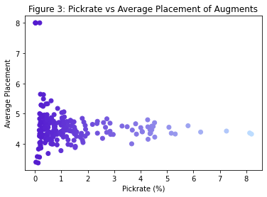

```python
ax3, fig3 = plt.subplots()

cmap = mpl.colors.LinearSegmentedColormap.from_list('', ['#541bcf', '#bdddff'])

norm = plt.Normalize(min(x), max(x))
colors = cmap(norm(x))

plt.scatter(x=x, y=y, color=colors)
plt.title('Figure 3: Pickrate vs Average Placement of Augments')
plt.xlabel('Pickrate (%)')
plt.ylabel('Average Placement')
```

```python
colors[0]
```

```
array([0.53287197, 0.48179931, 0.90477509, 1.        ])
```

```python
for i in range(len(x)):
    if x[i] > 8:
        print("Pickrate over 8 percent: " + keys[i])
    if y[i] < 4:
        print("Average Placement Below 4: " + keys[i])
```

```
Pickrate over 8 percent: TFT6_Augment_ComponentGrabBag
Pickrate over 8 percent: TFT6_Augment_PortableForge
Average Placement Below 4: TFT6_Augment_BrawlerHPRegen1
Average Placement Below 4: TFT6_Augment_Diversify3
Average Placement Below 4: TFT6_Augment_CelestialBlessing3
Average Placement Below 4: TFT6_Augment_BruteTrait
Average Placement Below 4: TFT6_Augment_WoodlandCharm
Average Placement Below 4: TFT6_Augment_CyberneticUplink3
Average Placement Below 4: TFT6_Augment_ClearMind
Average Placement Below 4: TFT6_Augment_ChemtechEmblem2
Average Placement Below 4: TFT6_Augment_EnchanterArdentCenser
Average Placement Below 4: TFT6_Augment_SlowAndSteady
Average Placement Below 4: TFT6_Augment_DebonairEmblem2
Average Placement Below 4: TFT6_Augment_Traitless3
Average Placement Below 4: TFT6_Augment_ChallengerEmblem2
Average Placement Below 4: TFT6_Augment_Electrocharge3
Average Placement Below 4: TFT6_Augment_Featherweights3
```

The Component Grab Bag and Portable Forge are powerful augments that were notably picked often, over 8 percent of the time. The augments with placements below 4 are augments that when picked on average yielded results that were top 4 and 'winning'.

## Augments and Their Placements for Each Trait

For each trait in the traits we are interested in (those not contained in the one off traits) we wish to have a way to visually see the best and worst augments for that trait. Thus, we will generate the graphs for several different traits, plotting the augments that had a sample size greater than thirty for that trait and the average placement of the augments.

First we get the list of the traits we are interested in and store it into real_traits. We also declare a list of lists data_array which will store rows for a new dataframe. Then for each trait in this list, we filter the dataframe for rows only containing the trait at a style 2 or greater. Next, we create a dictionary that will have as its keys the augments, and its values dictionaries. These sub dictionaries will all contain two entries, one accessible by 'count' which keeps track of number of occurrences, and one accessible by 'placement' which contains the sum of all the placements of the augments. Then, for each entry we check that the count is over 30, and add a list to the data_array containing the trait, augment, and average placement. At the end, we have a list of lists of every augment trait combination with more than 30 games played. We then convert this into the dataframe aug_rank to more easily graph the data. The reason we check that the number of games is over 30 is so that we know we have a statistically significant amount of games played for each trait augment pair.

```python
real_traits = [trait for trait in trait_names if trait not in one_off_traits]
data_array = list()
for trait in real_traits:
    trait_df = df[df[trait] >= 2]

    augment_freq = defaultdict(lambda: defaultdict(int))
    for index, row in trait_df.iterrows():
         for augment in ['Augment_1', 'Augment_2', 'Augment_3']:
            if type(row[augment]) != float:
                augment_freq[row[augment]]['count'] += 1
                augment_freq[row[augment]]['placement'] += row['Placement']

    for key, value in augment_freq.items():
        if value['count'] >= 30:
            new_row = list()
            new_row.append(trait)
            new_row.append(key)
            new_row.append(value['placement'] / value['count'])
            data_array.append(new_row)

aug_rank = pd.DataFrame(data = data_array, columns = ['Trait', 'Augment', 'Average Placement'])
```

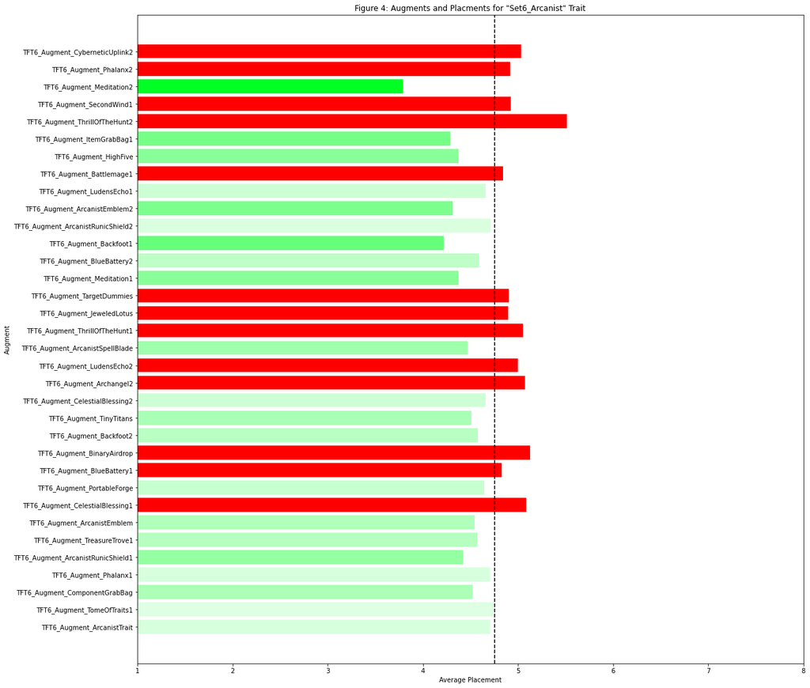

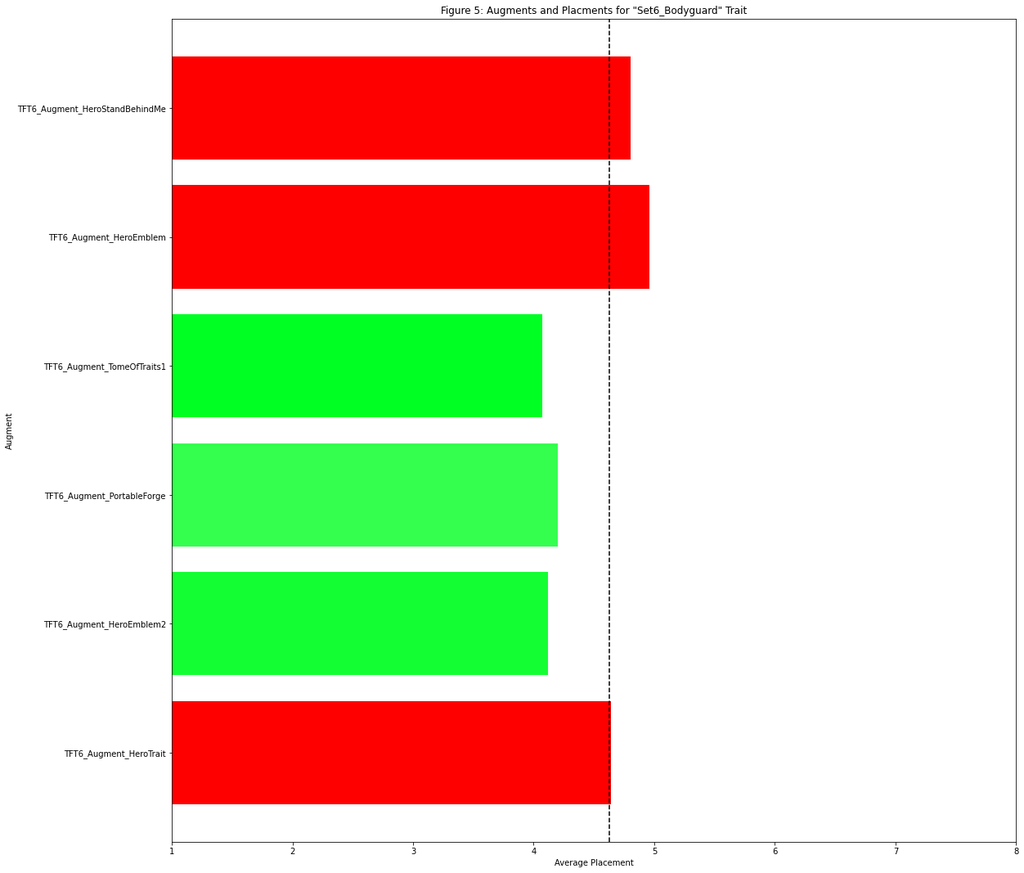

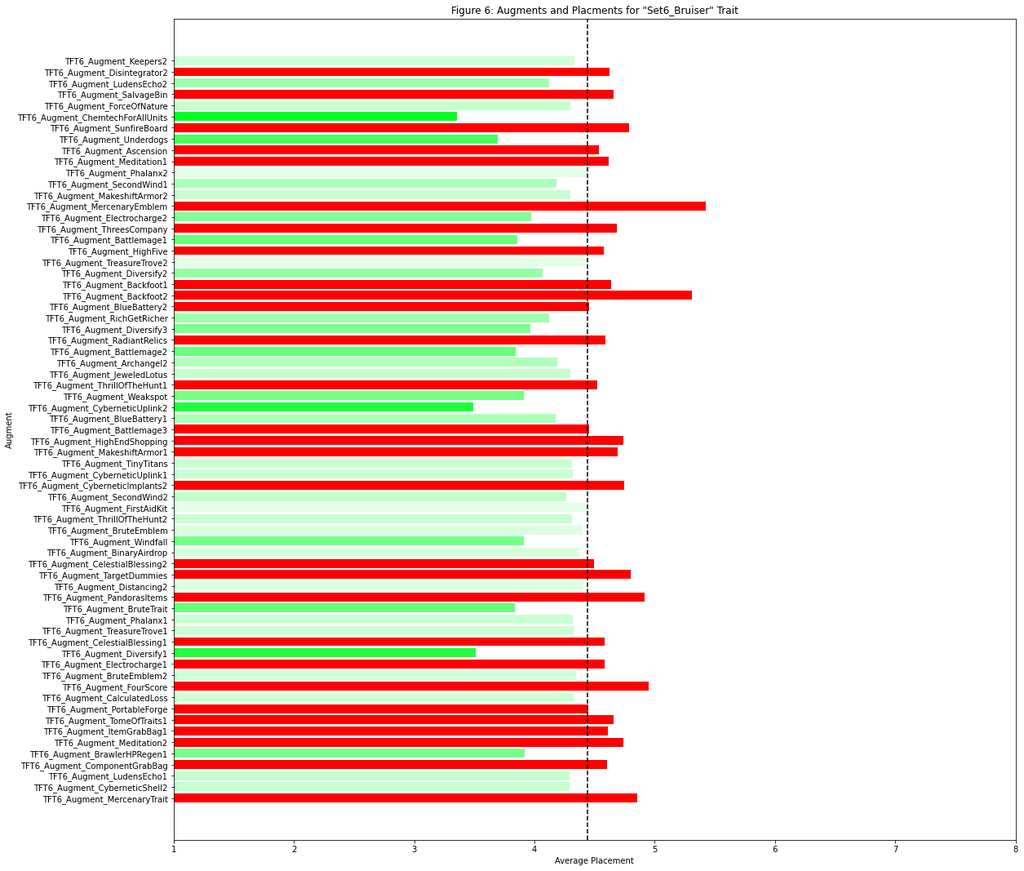

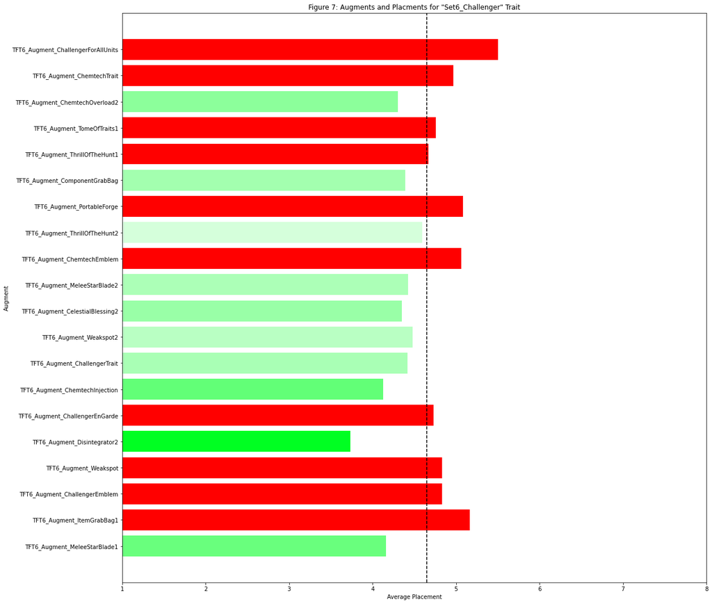

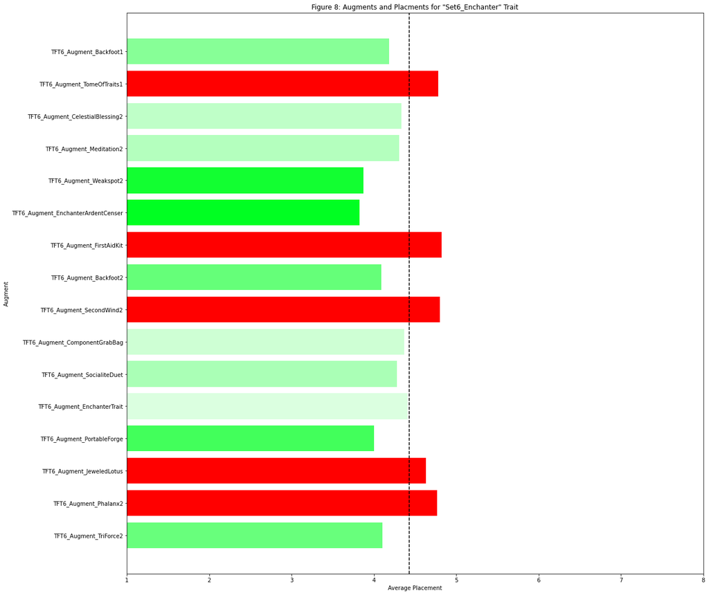

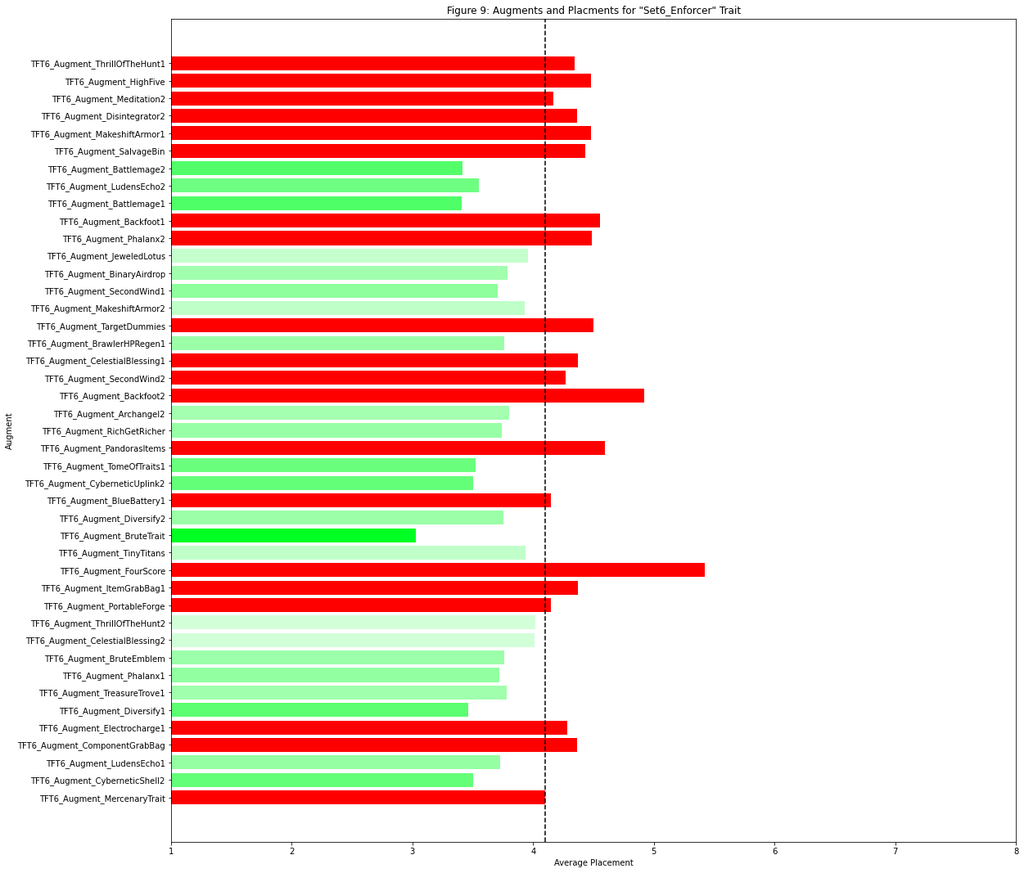

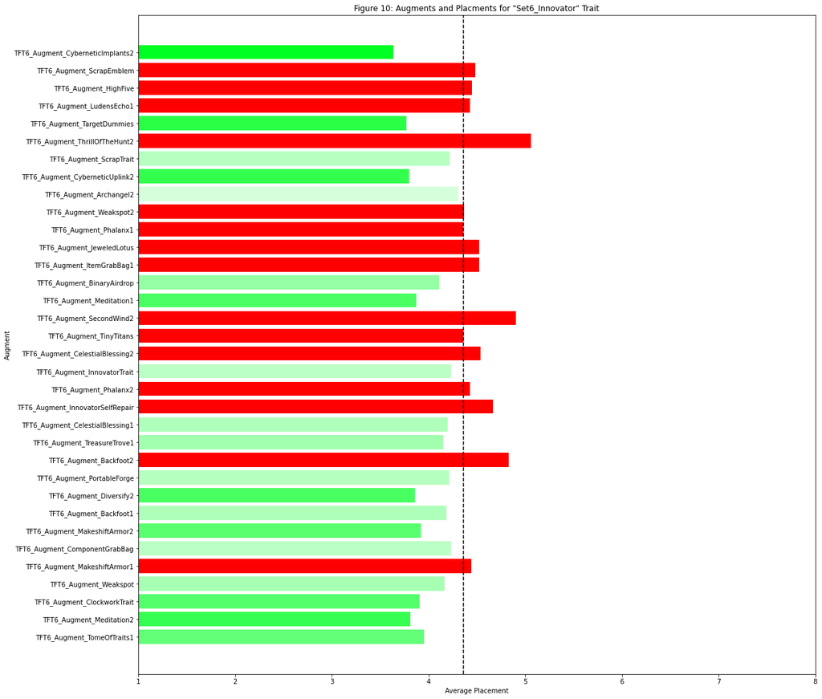

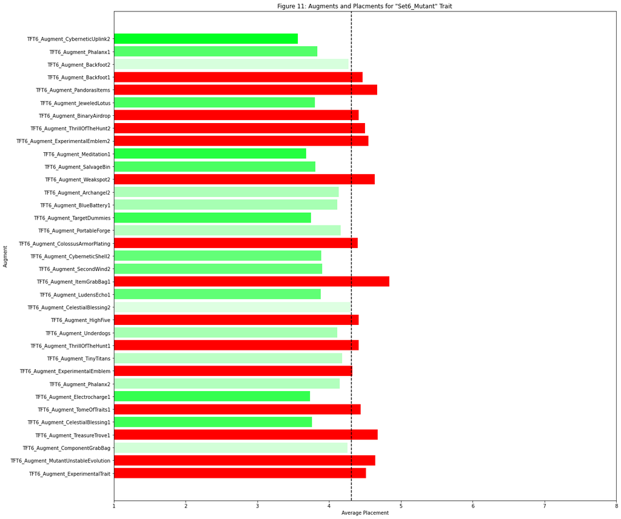

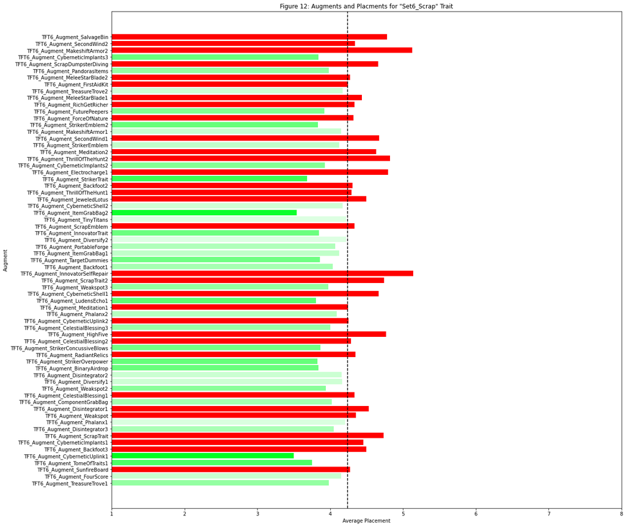

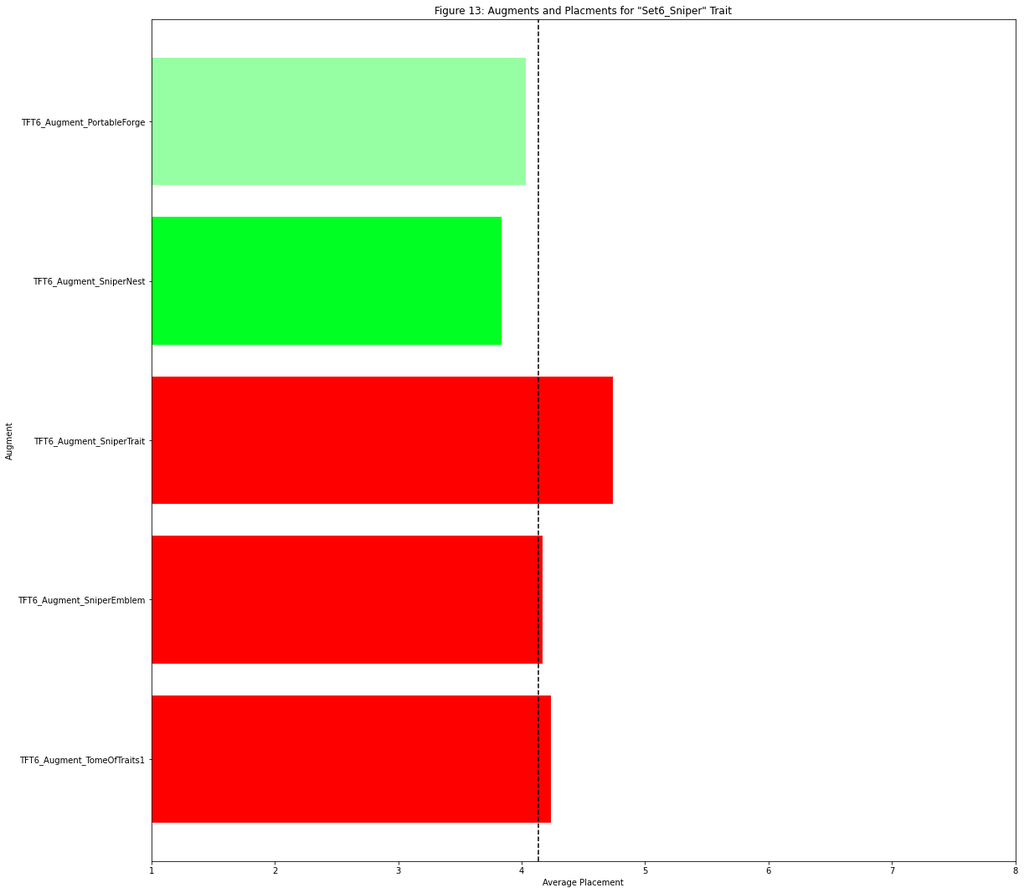

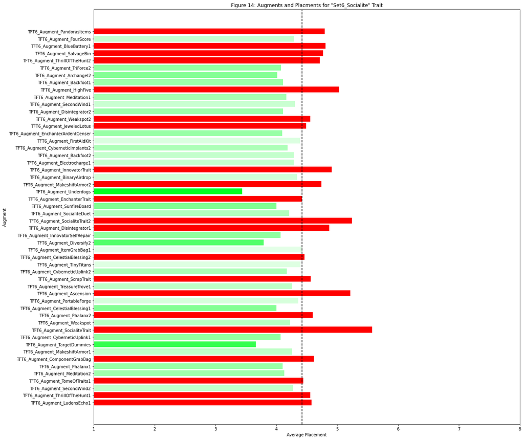

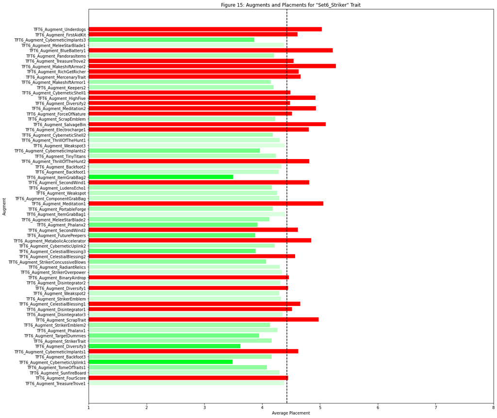

[2 more figures not shown]

```python
count = 4
for key, group in aug_rank.groupby('Trait'):
    if (len(group.index)) >= 5:
        fig, ax = plt.subplots()
        plt.title(f'Figure {count}: Augments and Placments for \"{key}\" Trait')
        count = count + 1
        plt.ylabel('Augment')
        plt.xlabel('Average Placement')
        fig.set_size_inches(18.5, 18.5)

        colors = list()

        x = group['Augment']
        y = group['Average Placement']

        cmap = mpl.colors.LinearSegmentedColormap.from_list('', ['#00ff22', '#e3ffe7'])
        norm = plt.Normalize(min(y), trait_placement[key][0])

        for val in y.values:
            if val < trait_placement[key][0]:
                colors.append(cmap(norm(val)))
            else:
                colors.append('red')

        ax.set(xlim=[1, 8])
        plt.barh(x, y, tick_label=group['Augment'], color=colors)
        plt.axvline(x=trait_placement[key][0], color="black", linestyle="--")
        plt.plot()
```